# Academic inbreeding at FEBA — network construction, centrality, and regressions

Reproduction of Приложение А1

Stoycho Rusinov

15 юни 2026

This document rebuilds the supervisor and jury network from `Book4.xlsx`, computes three centrality measures off the weighted adjacency matrix W, merges them onto the FEBA roster in `inbreeding_at_FEBA.xlsx`, and runs the regression battery. It is meant to knit top to bottom with the two spreadsheets sitting in a `data/` folder next to the file.

# 1 Name cleaning and canonicalisation

The same person is written several ways across the three columns. The rules below strip academic titles, repair stray Latin look-alike letters inside Cyrillic tokens, unify the missing-value tokens, and then merge spelling variants of one person while refusing to merge two people who share a surname under different patronymics.

```r
MISSING <- c("no info","no data","n/a","na","nan","")
LAT <- "aeopcxykmthBAEOPCXYKMTH"
CYR <- "\u0430\u0435\u043e\u0440\u0441\u0445\u0443\u043a\u043c\u0442\u043d\u0412\u0410\u0415\u041e\u0420\u0421\u0425\u0423\u041a\u041c\u0422\u041d"
TITLES <- c("\u043f\u0440\u043e\u0444\\.?","\u0434\u043e\u0446\\.?",
            "\u0433\u043b\\.?\\s*\u0430\u0441\\.?","\\b\u0430\u0441\\.",
            "\u0434\\.\u0438\u043a\\.\u043d\\.?","\u0434\\.\u043c\\.\u043d\\.?",
            "\u0434\\.\u043d\\.?","\u0434-\u0440")

fix_homoglyphs <- function(tok) {
  if (!stri_detect_regex(tok, "[\u0400-\u04ff]")) return(tok)
  chartr(LAT, CYR, tok)
}

clean_name <- function(raw) {
  if (is.na(raw) || !is.character(raw)) return(NA_character_)
  s <- gsub("\u00a0", " ", raw, fixed = TRUE)
  s <- stri_replace_all_regex(s, "\\p{C}", "")
  s <- stri_trim_both(stri_replace_all_regex(s, "\\s+", " "))
  if (tolower(s) %in% MISSING) return(NA_character_)
  s <- stri_trim_both(stri_replace_all_regex(
        s, "[-\u2013]\\s*(\u0437\u0430\u043c\\.?\\s*-?\\s*\u0434\u0435\u043a\u0430\u043d|\u0434\u0435\u043a\u0430\u043d).*$",
        "", case_insensitive = TRUE))
  for (pat in TITLES) s <- stri_replace_all_regex(s, pat, " ", case_insensitive = TRUE)
  s <- stri_trim_both(stri_replace_all_regex(s, "\\s+", " "))
  s <- gsub("^[ .,]+|[ .,]+$", "", s)
  if (s == "") return(NA_character_)
  toks <- strsplit(s, " ", fixed = TRUE)[[1]]
  s <- paste(vapply(toks, fix_homoglyphs, character(1)), collapse = " ")
  s <- gsub("^[ .,]+|[ .,]+$", "", s)
  if (s == "") NA_character_ else s
}

.toks       <- function(n) strsplit(n, " ", fixed = TRUE)[[1]]
.is_initial <- function(t) nchar(t) <= 2 && endsWith(t, ".")
.signature  <- function(n) { ts <- .toks(n); if (length(ts) == 1) c(ts[1], "") else c(ts[1], ts[length(ts)]) }
.patronymic <- function(n) {
  ts <- .toks(n)
  if (length(ts) >= 3 && !.is_initial(ts[2])) paste(ts[2:(length(ts) - 1)], collapse = " ") else NA_character_
}

canonicalise <- function(all_names) {
  sig_key <- vapply(all_names, function(n) paste(.signature(n), collapse = "\u0001"), character(1))
  canon <- setNames(all_names, all_names)
  for (key in unique(sig_key)) {
    members <- all_names[sig_key == key]
    patrs <- unique(stats::na.omit(vapply(members, .patronymic, character(1))))
    if (length(patrs) <= 1) {
      with_p <- members[!is.na(vapply(members, .patronymic, character(1)))]
      pool <- if (length(with_p)) with_p else members
      target <- pool[which.max(vapply(pool, function(x) length(.toks(x)) * 1000 + nchar(x), numeric(1)))]
      canon[members] <- target
    } else {
      canon[members] <- members
    }
  }
  canon
}

build_edges <- function(raw, canon) {
  out <- list()
  for (i in seq_len(nrow(raw))) {
    src <- clean_name(raw$Name[i]); if (is.na(src)) next
    s <- if (src %in% names(canon)) canon[[src]] else src
    for (cw in list(c("Advisor","advisor","1.0"), c("Joury_head","jury","0.5"))) {
      tgt <- clean_name(raw[[cw[1]]][i]); if (is.na(tgt)) next
      t <- if (tgt %in% names(canon)) canon[[tgt]] else tgt
      out[[length(out) + 1]] <- data.frame(source = s, target = t, relation = cw[2],
                                            weight = as.numeric(cw[3]), stringsAsFactors = FALSE)
    }
  }
  do.call(rbind, out)
}

# Conley / Kojevnikov network-robust covariance for an lm fit
network_robust_se <- function(model, frame, g, rho = 0.5) {
  nm <- frame$canon
  D  <- distances(g, v = nm, to = nm)
  K  <- rho ^ D; K[!is.finite(D)] <- 0
  X  <- model.matrix(model); u <- residuals(model)
  bread <- solve(crossprod(X))
  V <- bread %*% (t(X) %*% (K * (u %o% u)) %*% X) %*% bread
  sqrt(diag(V))
}

hc1_se <- function(model) {
  X <- model.matrix(model); u <- residuals(model)
  n <- nrow(X); k <- ncol(X); bread <- solve(crossprod(X))
  V <- bread %*% (t(X) %*% diag(u^2) %*% X) %*% bread * (n / (n - k))
  sqrt(diag(V))
}
```

# 2 Network and the adjacency matrix W

Ties are weighted 1.0 for a supervisor-doctoral relationship and 0.5 for a jury relationship, summed when a pair shares both, undirected, with a zero diagonal.

```r
raw <- as.data.frame(read_excel(file.path(DATA, "Book4.xlsx")))

all_names <- unique(stats::na.omit(unlist(lapply(
  c("Name","Advisor","Joury_head"),
  function(c) vapply(raw[[c]], clean_name, character(1))))))

canon <- canonicalise(all_names)
edges <- build_edges(raw, canon)

# self-loop guard: a student resolving to their own supervisor signals a bad merge
loop_rows <- edges[edges$source == edges$target, , drop = FALSE]
loop_sigs <- if (nrow(loop_rows))
  unique(apply(loop_rows, 1, function(r) paste(.signature(r[["source"]]), collapse = "\u0001"))) else character(0)
if (length(loop_sigs)) {
  sig_key <- vapply(all_names, function(n) paste(.signature(n), collapse = "\u0001"), character(1))
  for (k in loop_sigs) { m <- all_names[sig_key == k]; canon[m] <- m }
  edges <- build_edges(raw, canon)
}
edges <- edges[edges$source != edges$target, ]

g <- graph_from_data_frame(edges[, c("source","target","weight")], directed = FALSE)
g <- simplify(g, edge.attr.comb = list(weight = "sum"))

nodes_ord <- sort(V(g)$name)
W <- as.matrix(as_adjacency_matrix(g, attr = "weight"))[nodes_ord, nodes_ord]
stopifnot(isTRUE(all.equal(W, t(W))), all(diag(W) == 0))
write.csv(W, file.path(OUT, "W_full.csv"), fileEncoding = "UTF-8")

cat(sprintf("network: %d nodes, %d edges; W is %d x %d, max weight %.1f\n",
            gorder(g), gsize(g), nrow(W), ncol(W), max(W)))
```

```
## network: 142 nodes, 128 edges; W is 142 x 142, max weight 1.5
```

# 3 Centralities

Weighted degree is the node strength. Eigenvector centrality is computed on the giant component only and set to zero elsewhere, because the leading eigenvector of a fragmented graph concentrates in the dominant component. Katz centrality is computed on the full graph with alpha equal to a damping of 0.85 over the spectral radius, so isolates still receive a graded baseline.

```r
roster <- as.data.frame(read_excel(file.path(DATA, "inbreeding_at_FEBA.xlsx"),
                                    sheet = "main_database"))
roster <- roster[!is.na(roster$Name), ]
roster$canon <- vapply(roster$Name, function(x) {
  cc <- clean_name(x)
  if (is.na(cc)) NA_character_ else if (cc %in% names(canon)) canon[[cc]] else cc
}, character(1))

missing_v <- setdiff(unique(roster$canon), V(g)$name)
if (length(missing_v)) g <- add_vertices(g, length(missing_v), name = missing_v)

str_v <- strength(g, weights = E(g)$weight)

comp   <- components(g)
giant  <- which.max(comp$csize)
g_core <- induced_subgraph(g, V(g)[comp$membership == giant])
ev_core <- eigen_centrality(g_core, weights = E(g_core)$weight, scale = FALSE)$vector
eig_v <- setNames(rep(0, gorder(g)), V(g)$name); eig_v[names(ev_core)] <- ev_core

A   <- as.matrix(as_adjacency_matrix(g, attr = "weight"))
lam <- max(abs(eigen(A, only.values = TRUE)$values))
ALPHA <- params$katz_damping / lam
katz_v <- solve(diag(nrow(A)) - ALPHA * A, rep(1, nrow(A)))
names(katz_v) <- rownames(A)

roster$deg_strength <- unname(str_v[roster$canon]);  roster$deg_strength[is.na(roster$deg_strength)] <- 0
roster$eigen        <- unname(eig_v[roster$canon]);  roster$eigen[is.na(roster$eigen)] <- 0
roster$katz         <- unname(katz_v[roster$canon])
roster$in_giant     <- as.integer(roster$canon %in% V(g_core)$name)

cat(sprintf("faculty %d, matched %d, isolates %d, in giant %d; lambda_max %.3f, alpha %.4f\n",
            nrow(roster), sum(roster$canon %in% V(g)$name),
            sum(roster$deg_strength == 0), sum(roster$in_giant), lam, ALPHA))
```

```
## faculty 84, matched 84, isolates 12, in giant 42; lambda_max 2.672, alpha 0.3181
```

# 4 Outcome and control variables

The code below converts the dates, creates the dependent variables and prepares standardised centrality measures.

```r
fix_date <- function(x) {
  if (inherits(x, "Date")) return(x)
  if (inherits(x, "POSIXt")) return(as.Date(x))

  # Numeric Excel dates
  if (is.numeric(x)) {
    return(as.Date(x, origin = "1899-12-30"))
  }

  # Character dates and Excel dates stored as text
  x <- trimws(as.character(x))
  x[x %in% c("", "NA", "N/A", "-")] <- NA

  out <- as.Date(parse_date_time(
    x,
    orders = c("ymd HMS", "dmy HMS", "mdy HMS",
               "ymd", "dmy", "mdy", "Y"),
    quiet = TRUE
  ))

  excel_number <- suppressWarnings(as.numeric(x))
  use_excel <- is.na(out) & !is.na(excel_number) & excel_number > 10000
  out[use_excel] <- as.Date(excel_number[use_excel], origin = "1899-12-30")

  out
}

roster$PHD_Awarded <- fix_date(roster$PHD_Awarded)
roster$FIRST_PT_FEBA <- fix_date(roster$FIRST_PT_FEBA)

roster$delay_yrs <- as.numeric(
  roster$FIRST_PT_FEBA - roster$PHD_Awarded
) / 365.25

roster$Fast <- as.integer(roster$delay_yrs <= 1)
roster$cohort <- as.numeric(format(roster$PHD_Awarded, "%Y"))
roster$cohort_c <- roster$cohort - 2010
roster$POST_2010 <- as.integer(roster$cohort >= 2010)

roster$Scopus_all <- suppressWarnings(as.numeric(as.character(roster$Scopus_all)))
roster$log_scopus <- log1p(roster$Scopus_all)
roster$dept <- factor(trimws(as.character(roster$Department)))
roster$gender <- suppressWarnings(as.numeric(as.character(roster$Gender)))
roster$AI <- suppressWarnings(as.numeric(as.character(roster$AI)))

zpop <- function(x) {
  x <- as.numeric(x)
  s <- sqrt(mean((x - mean(x, na.rm = TRUE))^2, na.rm = TRUE))
  if (is.na(s) || s == 0) return(rep(0, length(x)))
  (x - mean(x, na.rm = TRUE)) / s
}

roster$z_deg_strength <- zpop(roster$deg_strength)
roster$z_eigen <- zpop(roster$eigen)
roster$z_katz <- zpop(roster$katz)

keep <- c(
  "Name", "canon", "dept", "cohort", "cohort_c", "POST_2010",
  "delay_yrs", "Fast", "AI", "Scopus_all", "log_scopus", "gender",
  "deg_strength", "eigen", "katz", "in_giant",
  "z_deg_strength", "z_eigen", "z_katz"
)

write.csv(
  roster[, keep],
  file.path(OUT, "feba_merged_centrality.csv"),
  row.names = FALSE,
  fileEncoding = "UTF-8"
)

cat("Non-missing PhD dates:", sum(!is.na(roster$PHD_Awarded)), "of", nrow(roster), "\n")
```

```
## Non-missing PhD dates: 82 of 84
```

```r
cat("Non-missing FEBA dates:", sum(!is.na(roster$FIRST_PT_FEBA)), "of", nrow(roster), "\n")
```

```
## Non-missing FEBA dates: 82 of 84
```

```r
cat("Non-missing delays:", sum(!is.na(roster$delay_yrs)), "of", nrow(roster), "\n")
```

```
## Non-missing delays: 81 of 84
```

# 5 Regression specifications

Each model uses one centrality measure at a time. Department controls are used when at least two departments remain in the usable estimation sample. This prevents the factor-contrast error caused by a one-level department variable.

## Model group 1 Academic inbreeding

```r
ai_data <- roster[complete.cases(roster[, c(
  "AI", "z_deg_strength", "z_eigen", "z_katz",
  "cohort_c", "log_scopus", "gender", "dept"
)]), ]
ai_data$dept <- droplevels(ai_data$dept)
ai_has_dept <- nlevels(ai_data$dept) >= 2

if (ai_has_dept) {
  ai_degree <- glm(AI ~ z_deg_strength + dept + cohort_c + log_scopus + gender,
                   data = ai_data, family = binomial)
  ai_eigen <- glm(AI ~ z_eigen + dept + cohort_c + log_scopus + gender,
                  data = ai_data, family = binomial)
  ai_katz <- glm(AI ~ z_katz + dept + cohort_c + log_scopus + gender,
                 data = ai_data, family = binomial)
} else {
  ai_degree <- glm(AI ~ z_deg_strength + cohort_c + log_scopus + gender,
                   data = ai_data, family = binomial)
  ai_eigen <- glm(AI ~ z_eigen + cohort_c + log_scopus + gender,
                  data = ai_data, family = binomial)
  ai_katz <- glm(AI ~ z_katz + cohort_c + log_scopus + gender,
                 data = ai_data, family = binomial)
}

stargazer(
  ai_degree, ai_eigen, ai_katz,
  type = "text",
  title = "Network centrality and academic inbreeding",
  column.labels = c("Degree", "Eigenvector", "Katz"),
  dep.var.labels = "Academic inbreeding",
  keep = c("z_deg_strength", "z_eigen", "z_katz",
           "cohort_c", "log_scopus", "gender"),
  covariate.labels = c(
    "Weighted degree centrality",
    "Eigenvector centrality",
    "Katz centrality",
    "PhD cohort centred at 2010",
    "Log Scopus publications",
    "Gender"
  ),
  add.lines = list(c("Department controls",
                     ifelse(ai_has_dept, "Yes", "No"),
                     ifelse(ai_has_dept, "Yes", "No"),
                     ifelse(ai_has_dept, "Yes", "No"))),
  keep.stat = c("n", "ll", "aic"),
  digits = 3,
  notes = "Logit coefficients.",
  notes.append = FALSE
)
```

```
##
## Network centrality and academic inbreeding
## ========================================================
##                                 Dependent variable:
##                            -----------------------------
##                                 Academic inbreeding
##                             Degree  Eigenvector   Katz
##                              (1)        (2)       (3)
## --------------------------------------------------------
## Weighted degree centrality  0.676
##                            (0.428)
##
## Eigenvector centrality               2.160***
##                                       (0.655)
##
## Katz centrality                                 2.726***
##                                                 (0.737)
##
## PhD cohort centred at 2010 0.222***  0.285***   0.336***
##                            (0.057)    (0.074)   (0.088)
##
## Log Scopus publications     -0.246     0.099     -0.299
##                            (0.320)    (0.356)   (0.419)
##
## Gender                      -0.506    -0.530     -1.335
##                            (0.639)    (0.758)   (0.986)
##
## --------------------------------------------------------
## Department controls          Yes        Yes       Yes
## Observations                  82        82         82
## Log Likelihood             -37.953    -29.760   -23.184
## Akaike Inf. Crit.           93.907    77.520     64.367
## ========================================================
## Note:                                Logit coefficients.
```

## Model group 2 Years from PhD to first FEBA appointment

```r
delay_data <- roster[complete.cases(roster[, c(
  "delay_yrs", "z_deg_strength", "z_eigen", "z_katz",
  "cohort_c", "log_scopus", "gender", "dept"
)]), ]
delay_data$dept <- droplevels(delay_data$dept)
delay_has_dept <- nlevels(delay_data$dept) >= 2

if (delay_has_dept) {
  delay_degree <- lm(delay_yrs ~ z_deg_strength + dept + cohort_c + log_scopus + gender,
                     data = delay_data)
  delay_eigen <- lm(delay_yrs ~ z_eigen + dept + cohort_c + log_scopus + gender,
                    data = delay_data)
  delay_katz <- lm(delay_yrs ~ z_katz + dept + cohort_c + log_scopus + gender,
                   data = delay_data)
} else {
  delay_degree <- lm(delay_yrs ~ z_deg_strength + cohort_c + log_scopus + gender,
                     data = delay_data)
  delay_eigen <- lm(delay_yrs ~ z_eigen + cohort_c + log_scopus + gender,
                    data = delay_data)
  delay_katz <- lm(delay_yrs ~ z_katz + cohort_c + log_scopus + gender,
                   data = delay_data)
}

stargazer(
  delay_degree, delay_eigen, delay_katz,
  type = "text",
  title = "Network centrality and appointment delay",
  column.labels = c("Degree", "Eigenvector", "Katz"),
  dep.var.labels = "Years from PhD to FEBA appointment",
  keep = c("z_deg_strength", "z_eigen", "z_katz",
           "cohort_c", "log_scopus", "gender"),
  covariate.labels = c(
    "Weighted degree centrality",
    "Eigenvector centrality",
    "Katz centrality",
    "PhD cohort centred at 2010",
    "Log Scopus publications",
    "Gender"
  ),
  add.lines = list(c("Department controls",
                     ifelse(delay_has_dept, "Yes", "No"),
                     ifelse(delay_has_dept, "Yes", "No"),
                     ifelse(delay_has_dept, "Yes", "No"))),
  keep.stat = c("n", "rsq", "adj.rsq", "f"),
  digits = 3,
  notes = "OLS coefficients.",
  notes.append = FALSE
)
```

```
##
## Network centrality and appointment delay
## ===============================================================
##                                    Dependent variable:
##                            ------------------------------------
##                             Years from PhD to FEBA appointment
##                               Degree    Eigenvector    Katz
##                                (1)          (2)         (3)
## ---------------------------------------------------------------
## Weighted degree centrality   -2.098*
##                              (1.105)
##
## Eigenvector centrality                   -2.410**
##                                           (1.095)
##
## Katz centrality                                      -3.417***
##                                                       (0.947)
##
## PhD cohort centred at 2010  -0.592***    -0.574***   -0.552***
##                              (0.113)      (0.111)     (0.106)
##
## Log Scopus publications       0.649       -0.119       0.319
##                              (1.016)      (0.969)     (0.919)
##
## Gender                        0.706       -0.300       0.457
##                              (1.908)      (1.857)     (1.767)
##
## ---------------------------------------------------------------
## Department controls            Yes          Yes         Yes
## Observations                    81          81          81
## R2                            0.373        0.383       0.442
## Adjusted R2                   0.303        0.314       0.380
## F Statistic (df = 8; 72)     5.344***    5.579***    7.129***
## ===============================================================
## Note:                                         OLS coefficients.
```

## Model group 3 Appointment within one year

```r
fast_data <- roster[complete.cases(roster[, c(
  "Fast", "z_deg_strength", "z_eigen", "z_katz",
  "cohort_c", "log_scopus", "gender", "dept"
)]), ]
fast_data$dept <- droplevels(fast_data$dept)
fast_has_dept <- nlevels(fast_data$dept) >= 2

if (fast_has_dept) {
  fast_degree <- glm(Fast ~ z_deg_strength + dept + cohort_c + log_scopus + gender,
                     data = fast_data, family = binomial)
  fast_eigen <- glm(Fast ~ z_eigen + dept + cohort_c + log_scopus + gender,
                    data = fast_data, family = binomial)
  fast_katz <- glm(Fast ~ z_katz + dept + cohort_c + log_scopus + gender,
                   data = fast_data, family = binomial)
} else {
  fast_degree <- glm(Fast ~ z_deg_strength + cohort_c + log_scopus + gender,
                     data = fast_data, family = binomial)
  fast_eigen <- glm(Fast ~ z_eigen + cohort_c + log_scopus + gender,
                    data = fast_data, family = binomial)
  fast_katz <- glm(Fast ~ z_katz + cohort_c + log_scopus + gender,
                   data = fast_data, family = binomial)
}

stargazer(
  fast_degree, fast_eigen, fast_katz,
  type = "text",
  title = "Network centrality and fast academic appointment",
  column.labels = c("Degree", "Eigenvector", "Katz"),
  dep.var.labels = "Appointment within one year",
  keep = c("z_deg_strength", "z_eigen", "z_katz",
           "cohort_c", "log_scopus", "gender"),
  covariate.labels = c(
    "Weighted degree centrality",
    "Eigenvector centrality",
    "Katz centrality",
    "PhD cohort centred at 2010",
    "Log Scopus publications",
    "Gender"
  ),
  add.lines = list(c("Department controls",
                     ifelse(fast_has_dept, "Yes", "No"),
                     ifelse(fast_has_dept, "Yes", "No"),
                     ifelse(fast_has_dept, "Yes", "No"))),
  keep.stat = c("n", "ll", "aic"),
  digits = 3,
  notes = "Logit coefficients.",
  notes.append = FALSE
)
```

```
##
## Network centrality and fast academic appointment
## ========================================================
##                                 Dependent variable:
##                            -----------------------------
##                             Appointment within one year
##                             Degree  Eigenvector   Katz
##                              (1)        (2)       (3)
## --------------------------------------------------------
## Weighted degree centrality  0.486
##                            (0.399)
##
## Eigenvector centrality                -0.070
##                                       (0.328)
##
## Katz centrality                                  0.581*
##                                                 (0.318)
##
## PhD cohort centred at 2010 0.184***  0.168***   0.174***
##                            (0.050)    (0.046)   (0.048)
##
## Log Scopus publications     0.137      0.241     0.259
##                            (0.300)    (0.283)   (0.294)
##
## Gender                      -0.298    -0.203     -0.259
##                            (0.581)    (0.577)   (0.584)
##
## --------------------------------------------------------
## Department controls          Yes        Yes       Yes
## Observations                  81        81         81
## Log Likelihood             -42.586    -43.329   -41.595
## Akaike Inf. Crit.          103.172    104.658   101.189
## ========================================================
## Note:                                Logit coefficients.
```

## Model group 4 Cox proportional-hazards models

```r
cox_data <- roster[complete.cases(roster[, c(
  "delay_yrs", "z_deg_strength", "z_eigen", "z_katz",
  "cohort_c", "log_scopus", "gender", "POST_2010", "dept"
)]), ]
cox_data$dept <- droplevels(cox_data$dept)
cox_has_dept <- nlevels(cox_data$dept) >= 2

cox_data$duration <- cox_data$delay_yrs - min(cox_data$delay_yrs) + 0.01
cox_data$event <- 1

if (cox_has_dept) {
  cox_degree <- coxph(Surv(duration, event) ~ z_deg_strength + dept + cohort_c +
                        log_scopus + gender + POST_2010, data = cox_data)
  cox_eigen <- coxph(Surv(duration, event) ~ z_eigen + dept + cohort_c +
                       log_scopus + gender + POST_2010, data = cox_data)
  cox_katz <- coxph(Surv(duration, event) ~ z_katz + dept + cohort_c +
                      log_scopus + gender + POST_2010, data = cox_data)
} else {
  cox_degree <- coxph(Surv(duration, event) ~ z_deg_strength + cohort_c +
                        log_scopus + gender + POST_2010, data = cox_data)
  cox_eigen <- coxph(Surv(duration, event) ~ z_eigen + cohort_c +
                       log_scopus + gender + POST_2010, data = cox_data)
  cox_katz <- coxph(Surv(duration, event) ~ z_katz + cohort_c +
                      log_scopus + gender + POST_2010, data = cox_data)
}

stargazer(
  cox_degree, cox_eigen, cox_katz,
  type = "text",
  title = "Network centrality and appointment hazard",
  column.labels = c("Degree", "Eigenvector", "Katz"),
  dep.var.labels = "Appointment hazard",
  keep = c("z_deg_strength", "z_eigen", "z_katz",
           "cohort_c", "log_scopus", "gender", "POST_2010"),
  covariate.labels = c(
    "Weighted degree centrality",
    "Eigenvector centrality",
    "Katz centrality",
    "PhD cohort centred at 2010",
    "Log Scopus publications",
    "Gender",
    "Post-2010 PhD cohort"
  ),
  add.lines = list(c("Department controls",
                     ifelse(cox_has_dept, "Yes", "No"),
                     ifelse(cox_has_dept, "Yes", "No"),
                     ifelse(cox_has_dept, "Yes", "No"))),
  keep.stat = c("n", "ll"),
  digits = 3,
  notes = "Cox coefficients. Positive coefficients imply a higher appointment hazard.",
  notes.append = FALSE
)
```

```
##
## Network centrality and appointment hazard
## =======================================================================================================
##                                                        Dependent variable:
##                            ----------------------------------------------------------------------------
##                                                         Appointment hazard
##                                     Degree                  Eigenvector                  Katz
##                                       (1)                       (2)                      (3)
## -------------------------------------------------------------------------------------------------------
## Weighted degree centrality           0.270
##                                     (0.193)
##
## Eigenvector centrality                                         0.182
##                                                               (0.156)
##
## Katz centrality                                                                        0.472***
##                                                                                        (0.162)
##
## PhD cohort centred at 2010         0.105***                  0.107***                  0.121***
##                                     (0.030)                   (0.030)                  (0.031)
##
## Log Scopus publications              0.009                     0.048                    0.037
##                                     (0.141)                   (0.142)                  (0.140)
##
## Gender                              -0.045                     0.020                    0.027
##                                     (0.258)                   (0.257)                  (0.256)
##
## Post-2010 PhD cohort                 0.643                     0.455                    0.220
##                                     (0.484)                   (0.505)                  (0.504)
##
## -------------------------------------------------------------------------------------------------------
## Department controls                   Yes                       Yes                      Yes
## Observations                          81                        81                        81
## Log Likelihood                     -250.804                  -251.132                  -247.646
## =======================================================================================================
## Note:                        Cox coefficients. Positive coefficients imply a higher appointment hazard.
```

# 6 Figures

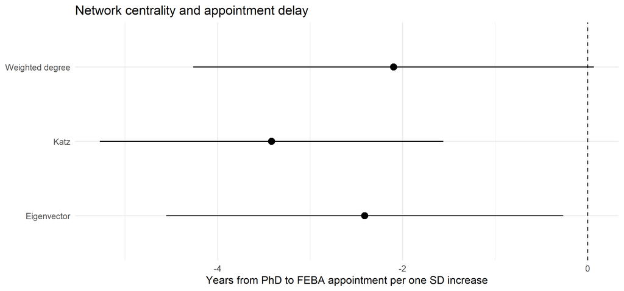

```r
fp <- data.frame(
  Centrality = c("Weighted degree", "Eigenvector", "Katz"),
  Estimate = c(
    coef(delay_degree)["z_deg_strength"],
    coef(delay_eigen)["z_eigen"],
    coef(delay_katz)["z_katz"]
  ),
  SE = c(
    summary(delay_degree)$coefficients["z_deg_strength", "Std. Error"],
    summary(delay_eigen)$coefficients["z_eigen", "Std. Error"],
    summary(delay_katz)$coefficients["z_katz", "Std. Error"]
  )
)

fp$lo <- fp$Estimate - 1.96 * fp$SE
fp$hi <- fp$Estimate + 1.96 * fp$SE

ggplot(fp, aes(Estimate, Centrality)) +
  geom_vline(xintercept = 0, linetype = "dashed") +
  geom_errorbarh(aes(xmin = lo, xmax = hi), height = 0) +
  geom_point(size = 3) +
  labs(
    title = "Network centrality and appointment delay",
    x = "Years from PhD to FEBA appointment per one SD increase",
    y = NULL
  ) +
  theme_minimal()
```

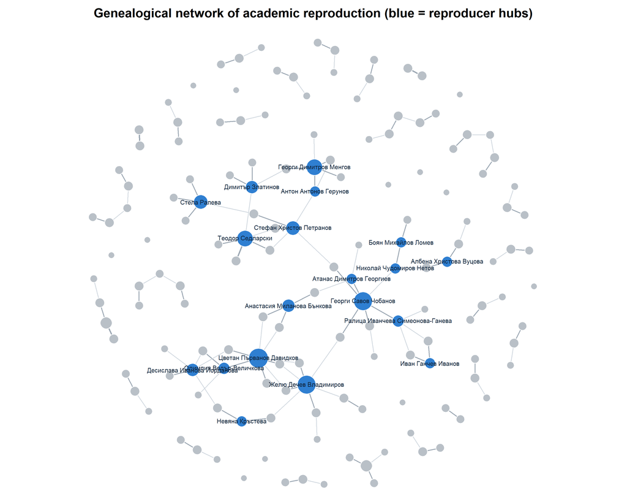

```r
repcount <- table(edges$target)
core <- intersect(V(g_core)$name, names(repcount)[repcount >= 1])
core <- core[str_v[core] >= 2.0]
vcol <- ifelse(V(g)$name %in% core, "#2f7fd1", "#b9c0c7")
vsz  <- 3 + 6 * (str_v[V(g)$name] / max(str_v))
set.seed(11); lay <- norm_coords(layout_with_fr(g, weights = E(g)$weight), -1, 1, -1, 1)
op <- par(mar = c(0, 0, 2, 0))
plot(g, layout = lay, rescale = FALSE,
     vertex.color = vcol, vertex.frame.color = "white",
     vertex.size = vsz, vertex.label = NA,
     edge.color = ifelse(E(g)$weight >= 1, "#9aa6b2", "#cdd5dd"),
     edge.width = 0.5 + E(g)$weight)
idx <- which(V(g)$name %in% core)
text(lay[idx, 1], lay[idx, 2], labels = V(g)$name[idx], cex = 0.6, col = "#10243a")
title("Genealogical network of academic reproduction (blue = reproducer hubs)")
```

```r
par(op)
```